# ICF Results Publication 2023 [DRAFT]: OFFICIAL-SENSITIVE

FCDO, DESNZ and Defra ICF teams

30 Aug 2023

> **Following voluntary compliance with the code of practice for official statistics, pre-release access to this report and associated data should be treated as official-sensitive and access limited to the core team involved in the publication process. Please do not distribute this report more widely.**

## ICF

International Climate Finance (ICF) is Official Development Assistance (ODA) from the UK to support developing countries to reduce poverty and respond to the challenges caused by climate change and environmental degradation. These investments help developing countries to:

• adapt and build resilience to the current and future effects of climate change

• pursue low-carbon development

• support sustainable management of natural resources

• increase access to clean energy

• reduce deforestation

Developed countries have jointly committed to mobilising $100 billion dollars a year in climate finance a year by 2020, to support developing countries to adapt to and mitigate the impacts of climate change[^1]. This target is expected to be reached by 2023. However, the IPCC estimates that between $1.6 trillion to $3.8 trillion will be needed each year to 2050 for the world to transition to a low-carbon future and to avoid warming beyond 1.5°C.

The UK has committed to spending £11.6 billion of ICF between financial years 2021/22 to 2025/26, with £3 billion of this to be invested in climate change solutions that protect, restore and sustainably manage nature. This budget represents a doubling of the UK’s previous ICF commitment of £5.8 billion between 2016/17-2020/21. Previously, £3.8 billion was spent from 2011/12-2015/16.

The ICF portfolio is delivered jointly across three UK Government Departments: the Foreign Commonwealth & Development Office (FCDO); the Department for Energy Security and Net Zero (DESNZ formerly the Department for Business, Energy and Industrial Strategy); and the Department for Environment, Food & Rural Affairs (Defra).

## Climate change

The UN has warned that “the world is on the brink of a climate catastrophe, and the window to avert it is closing rapidly”[^2]. In 2022, the global mean temperature was approximately 1.13°C above the pre-industrial level, making it one of the warmest years on record. To limit warning to 1.5°C, as set out in the Paris Agreement, requires a 43% decrease in global greenhouse gas emissions by 2030, and net zero by 2050.

The latest assessment from the International Panel on Climate Change sets out how human-induced climate change is already having devastating impacts globally, and yet greenhouse gas emissions have continued to rise between 2020-2019[^3]. The report emphasises the interdependence of climate, ecosystems and biodiversity, and human society, and the need for an integrated approach across these areas to solve the challenges we face. Every year the window for action gets smaller, while the risks we face become more complex and dangerous. The impacts of climate changes extend across the Sustainable Development Goals[^4], with increased extreme weather events already driving mass mortalities in plant and animal species, and millions of people increasingly exposed to food and water insecurity.

While the IPCC assessment stressed the severity of the situation, it also outlines how it is still possible to achieve the necessary emissions reductions to keep global warming to 1.5°C[^5], while every 0.1°C of heating we avoid will improve our chances of limiting climate catastrophe. Major transitions will be required in the energy sector to reduce our dependence on fossil fuels, alongside improvements in urban design and transport to reduce energy consumption. More efficient use and recycling of resources in industry and improvements in agriculture and land use will also be key areas for progress, helping to reduce greenhouse gas emissions while providing co-benefits for nature. Significant progress was made at the United Nations Climate Change Conference (COP26), hosted by the UK in 2021. The Glasgow Climate Pact was agreed, which set out ambitious commitments to ramp up action on climate change[^6]. These include phasing down coal and ending fossil fuel subsidies for the first time, over 90% of the global economy now covered by net zero pledges, and increased support to developing countries, including at least doubling adaptation finance to $40bn a year by 2025. If countries live up to the promises made at Glasgow, warming could be limited to below 2°C, but increased action is needed to keep us to the lower 1.5°C ceiling set out in the Paris Agreement[^7]. The UK will work closely with the incoming COP27 presidency, Egypt, to push for scaling up commitments in the next round of negotiations.

# ICF Results 2022/23

Changes since 20/09/22:  
• all plots updates to meet GSS guidelines

• kpi15 plot updated to show proportions

• expected total benefits corrected with refreshed data **WHAT IS THIS?????**

• kpi 8 and 10 corrected for Brazil programme (low impact) **WHAT IS THIS?????**

• corrections made for prog 300123, resulting in significant decrease for kpi 2, and some small increases for kpi 7, 11 and 12. **WHAT IS THIS???**

• programme counts for disaggregations fixed **WHAT IS THIS?????**

• list of revisions of historical results fixed to show all programme changes. **WHAT IS THIS?????**

### Total Achieved Results

Total cumulative results for each KPI, and the additional results from the latest reporting year:

| KPI Number | KPI Title | Achieved Total |
| --- | --- | --- |
| KPI 01 | Number of people supported to better adapt to the effects of climate change as a result of ICF | 101,506,000 People |
| KPI 02.1 | Number of people with improved access to clean energy as a result of ICF | 69,104,000 People |
| KPI 02.2 | Number of social institutions with improved access to clean energy as a result of ICF | 271 Institutions |
| KPI 04 | Number of people whose resilience has been improved as a result of ICF | 32,254,000 People |
| KPI 06 | Tonnes of Greenhouse Gas Emissions Reduced or Avoided as a result of ICF | 86,729,000 Tonnes of CO2 (tCO2e) |
| KPI 07 | Installed capacity of clean energy as a result of ICF | 4,678 Megawatts (MW) |
| KPI 08 | Ecosystem Loss Avoided as a result of ICF | 412,000 Hectares |
| KPI 10 | Value of ecosystem services generated or protected as a result of ICF | 5,302,000 GBP (£) |
| KPI 11 | Volume of public finance mobilised for climate change purposes as a result of ICF | 6,971,960,000 GBP (£) |
| KPI 12 | Volume of private finance mobilised for climate change purposes as a result of ICF | 6,918,256,000 GBP (£) |
| KPI 15 | Extent to which ICF intervention is likely to lead to transformational change | [Scorecard breakdown in KPI 15 section] |
| KPI 17 | Area under sustainable management practices as a result of ICF | 2,700,000 Hectares |
| TA KPI 01 | Number of Countries Supported by ICF Technical Assistance | 124 Countries |
| TA KPI 02.1 | Number of individuals supported by ICF Technical Assistance | 174,000 People |
| TA KPI 02.2 | Number of organisations supported by ICF Technical Assistance | 1,504 Organisations |
| TA KPI 03 | Number of climate policies informed by ICF Technical Assistance | 134 Policies |
| TA KPI 05 | Volume of emissions reductions avoided/supported by ICF technical assistance | 35,001,000 Tonnes of CO2 (tCO2e) |

### KPI 1

Total achieved from 2011-2023: 101,506,000 People

Increase in 2022/23: 6,876,000

Percentage increase since 2022: 6.77

How many programmes reported: 129

In 2022 the reported cumulative total was:94,629,523

The historical results for this KPI have been revised by: 777,000

The largest increases in results for this KPI in 2022/2023 have come from the following programmes:

| programme_id | programme_title | tot |
| --- | --- | --- |
| 203809 | Disaster Risk Insurance | 11516700 |
| 300751 | Global Risk Financing Facility [GRIF] | 9186680 |
| 203185 | Asia Regional Resilience to a changing climate (ARRCC) | 2306228 |
| 205145 | Nepal Health Sector Programme III | 2200000 |
| 204794 | Infrastructure for Climate Resilient Growth in India | 1772069 |

Cumulative annual results:

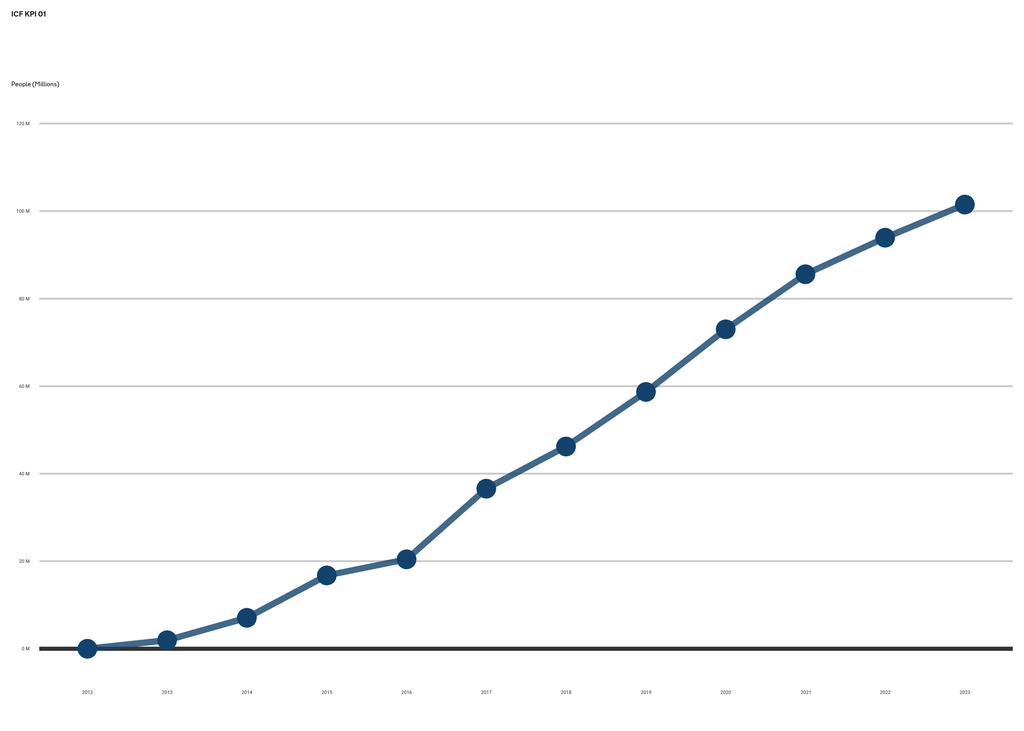

### KPI 2.1

Total achieved from 2011-2023: 69,104,000 People

Increase in 2022/23: 11,526,000

Percentage increase since 2022: 16.68

How many programmes reported: 51

In 2022 the reported cumulative total was:57,578,249

The historical results for this KPI have been revised by: 56,000

The largest increases in results for this KPI in 2022/2023 have come from the following programmes:

| programme_id | programme_title | tot |
| --- | --- | --- |
| 204867 | TEA - Transforming Energy Access | 6022250 |
| 300111 | Low Energy Inclusive Appliances | 1773887 |
| 300351 | Second phase of DFID’s Support to the Private Infrastructure Development Group (PIDG). | 1630495 |
| 204837 | BRILHO - Energy Africa Mozambique | 1118295 |
| 301517 | Renewable Energy Performance Platform (REPP) | 652455 |

Cumulative annual results:

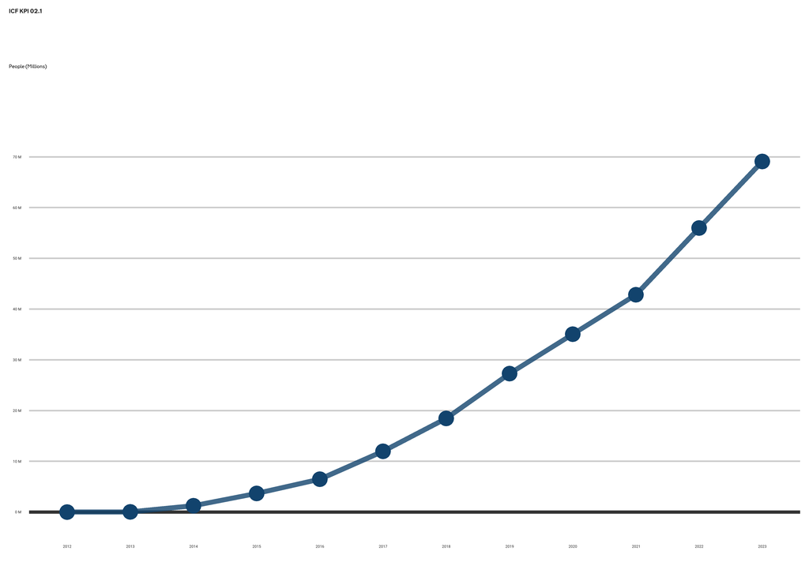

### KPI 2.2

Total achieved from 2011-2023: 271 Institutions

Increase in 2022/23: 47

Percentage increase since 2022: 17.34

How many programmes reported: 9

In 2022 the reported cumulative total was:224

The historical results for this KPI have been revised by: 7

The largest increases in results for this KPI in 2022/2023 have come from the following programmes:

| programme_id | programme_title | tot |
| --- | --- | --- |
| 301583 | Humanitarian Response Pakistan - 2022 Floods | 20 |
| 300857 | Better Lives for Somali Women and Children | 12 |
| 301240 | Enabling Development for Girls Education | 6 |
| 203272 | Strengthening Health Facilities in the Caribbean | 4 |
| 300123 | MECS - Modern Energy Cooking Services | 4 |

Cumulative annual results:

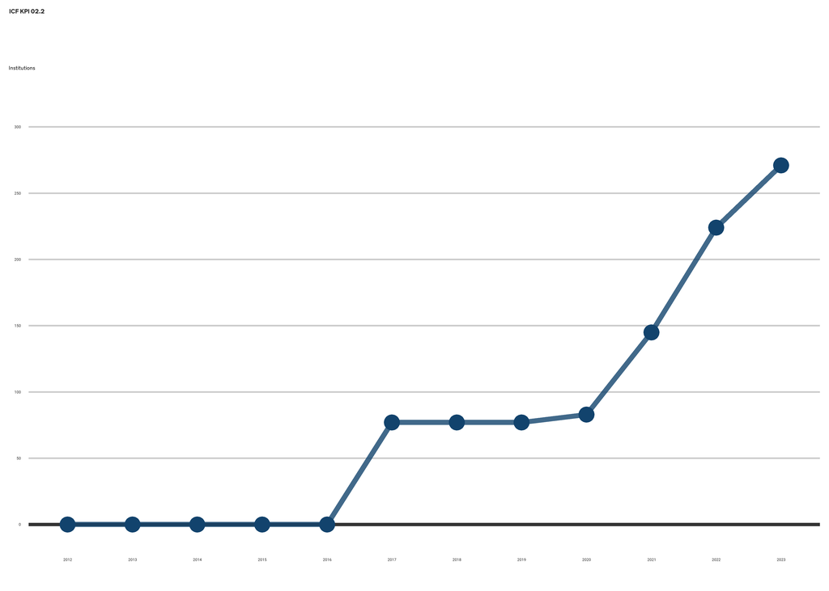

### KPI 4

Total achieved from 2011-2023: 32,254,000 People

Increase in 2022/23: 1,387,000

Percentage increase since 2022: 4.30

How many programmes reported: 28

In 2022 the reported cumulative total was:30,866,933

The historical results for this KPI have been revised by: 1,171,000

The largest increases in results for this KPI in 2022/2023 have come from the following programmes:

| programme_id | programme_title | tot |
| --- | --- | --- |
| 300725 | Transforming Access to WASH and Nutrition Services in Mozambique | 134320.00 |
| 300147 | Reducing Insecurity and Violent Extremism in the Northern Territories (Re-INVENT) | 42000.00 |
| 203551 | Tackling Maternal and Child Undernutrition Programme- Phase II | 31655.52 |
| 300116 | Productivity for Prosperity (P4P) | 4963.00 |
| 301583 | Humanitarian Response Pakistan - 2022 Floods | 2017.00 |

Cumulative annual results:

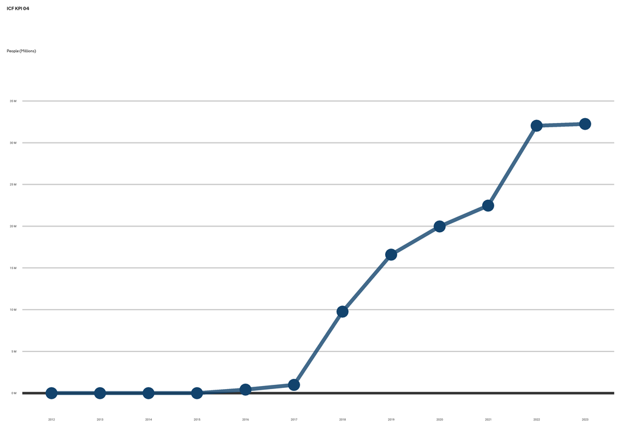

### KPI 6

Total achieved from 2011-2023: 86,729,000 Tonnes of CO2 (tCO2e)

Increase in 2022/23: 18,247,000

Percentage increase since 2022: 21.04

How many programmes reported: 57

In 2022 the reported cumulative total was:68,481,935

The historical results for this KPI have been revised by: -3,219,335

The largest increases in results for this KPI in 2022/2023 have come from the following programmes:

| programme_id | programme_title | tot |
| --- | --- | --- |
| 300418 | UK-INDIA Partnership on National Investment and Infrastructure Fund -Green Growth Equity Fund | 7483491 |
| BEIS0019 | REDD Early Movers programme (REM) | 7157050 |
| 200368 | Support to the multilateral Climate Investment Funds (CIFs) | 3507374 |
| BEIS0017 | Forest Carbon Partnership Facility (FCPF -C) - Carbon Fund | 519108 |
| 300632 | Strengthening Impact Investment Markets for Agriculture (SIIMA) | 426870 |

Cumulative annual results:

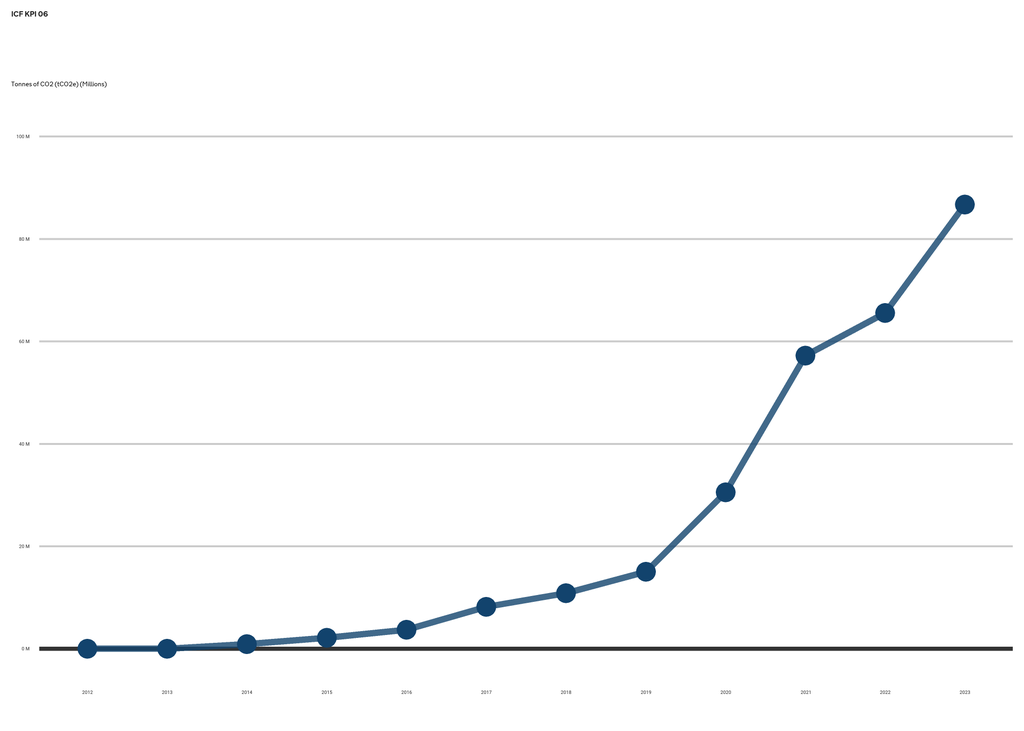

### KPI 7

Total achieved from 2011-2023: 4,678 Megawatts (MW)

How many programmes reported: 47

The historical results for this KPI have been revised by: 70

The largest increases in results for this KPI in 2022/2023 have come from the following programmes:

| programme_id | programme_title | tot |
| --- | --- | --- |
| 204837 | BRILHO - Energy Africa Mozambique | 1048.00 |
| 200368 | Support to the multilateral Climate Investment Funds (CIFs) | 350.70 |
| 203444 | CDC Programme of Support in Africa and South Asia (2015-2023) | 114.30 |
| 300418 | UK-INDIA Partnership on National Investment and Infrastructure Fund -Green Growth Equity Fund | 76.01 |
| 300351 | Second phase of DFID’s Support to the Private Infrastructure Development Group (PIDG). | 50.70 |

Cumulative annual results:

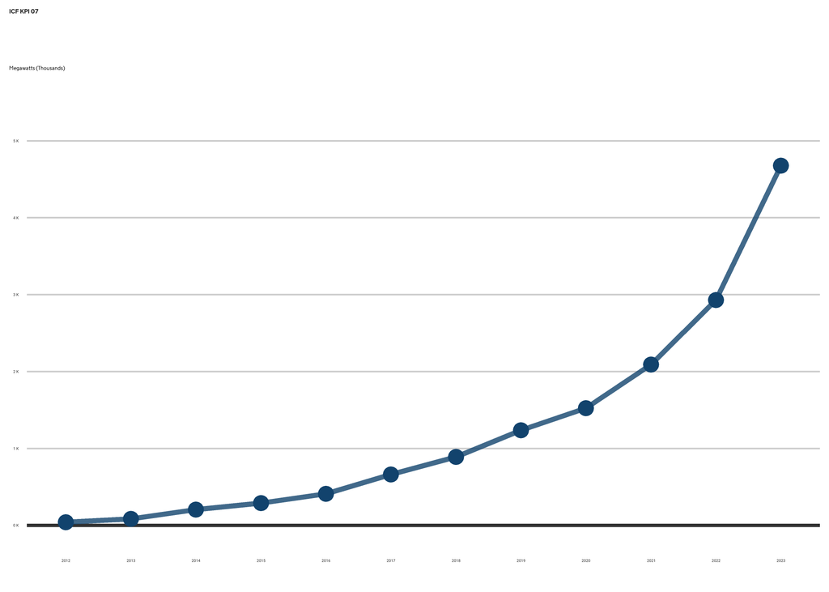

### KPI 8

Total achieved from 2011-2023: 412,000 Hectares

How many programmes reported: 15

The historical results for this KPI have been revised by: -6,258

The largest increases in results for this KPI in 2022/2023 have come from the following programmes:

| programme_id | programme_title | tot |
| --- | --- | --- |
| BEIS0019 | REDD Early Movers programme (REM) | 12639 |
| BEIS0017 | Forest Carbon Partnership Facility (FCPF -C) - Carbon Fund | 469 |
| 204984 | Climate Smart Development for Nepal | 15 |

Cumulative annual results:

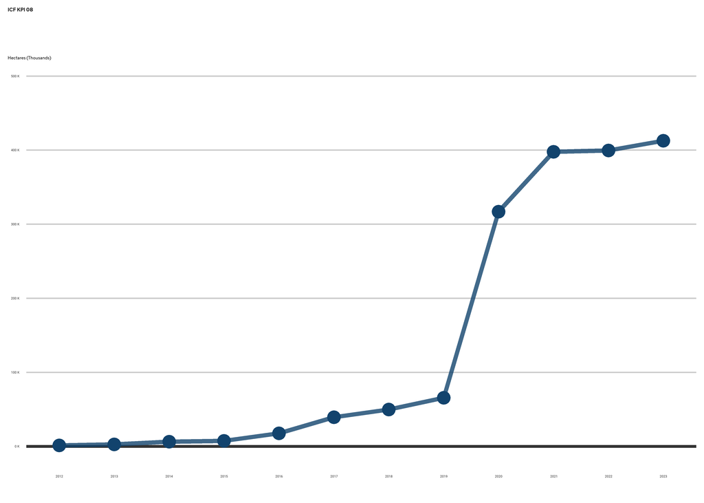

### KPI 10

Total achieved from 2011-2023: 5,302,000 GBP (£)

Increase in 2022/23: 49,000

How many programmes reported: 3

In 2022 the reported cumulative total was:5,253,180

The historical results for this KPI have been revised by: 120,000

| programme_id | programme_title | tot |
| --- | --- | --- |

Cumulative annual results:

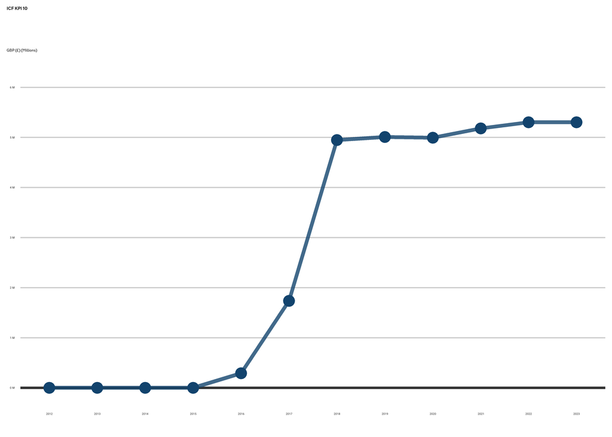

### KPI 11

Total achieved from 2011-2023: 6,971,960,000 GBP (£)

Increase in 2022/23: 1,304,539,000

Percentage increase since 2022: 18.71

How many programmes reported: 75

In 2022 the reported cumulative total was:5,667,421,486

The historical results for this KPI have been revised by: 120,990,000

The largest increases in results for this KPI in 2022/2023 have come from the following programmes:

| programme_id | programme_title | tot |
| --- | --- | --- |
| 300057 | Global Environment Facility 7th replenishment | 458905795 |
| 204867 | TEA - Transforming Energy Access | 177299565 |
| BEIS0032 | Market Accelerator for Green Construction (MAGC) | 135993408 |
| 205222 | Cities and Infrastructure for Growth (CIG) | 100480000 |
| 200368 | Support to the multilateral Climate Investment Funds (CIFs) | 83536419 |

Cumulative annual results:

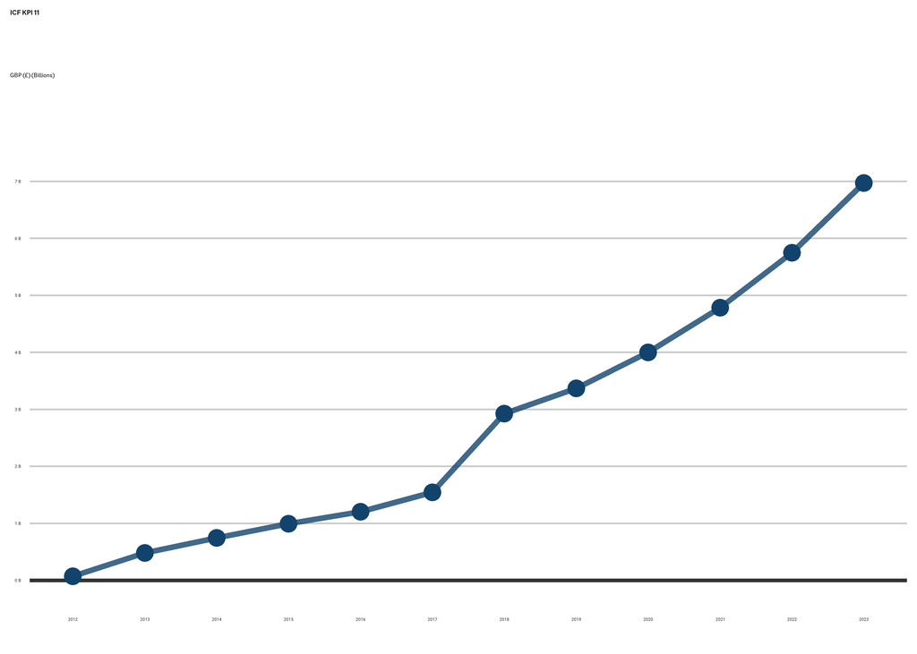

### KPI 12

Total achieved from 2011-2023: 6,918,256,000 GBP (£)

Increase in 2022/23: 1,767,672,000

Percentage increase since 2022: 25.55

How many programmes reported: 74

In 2022 the reported cumulative total was:5,150,584,716

The historical results for this KPI have been revised by: 373,269,000

The largest increases in results for this KPI in 2022/2023 have come from the following programmes:

| programme_id | programme_title | tot |
| --- | --- | --- |
| 203444 | CDC Programme of Support in Africa and South Asia (2015-2023) | 382952705 |
| 300057 | Global Environment Facility 7th replenishment | 159532836 |
| 301516 | Sustainable Infrastructure Programme - Latin America (SIP LA) | 157000000 |
| 204867 | TEA - Transforming Energy Access | 123041254 |
| 300351 | Second phase of DFID’s Support to the Private Infrastructure Development Group (PIDG). | 122172000 |

Cumulative annual results:

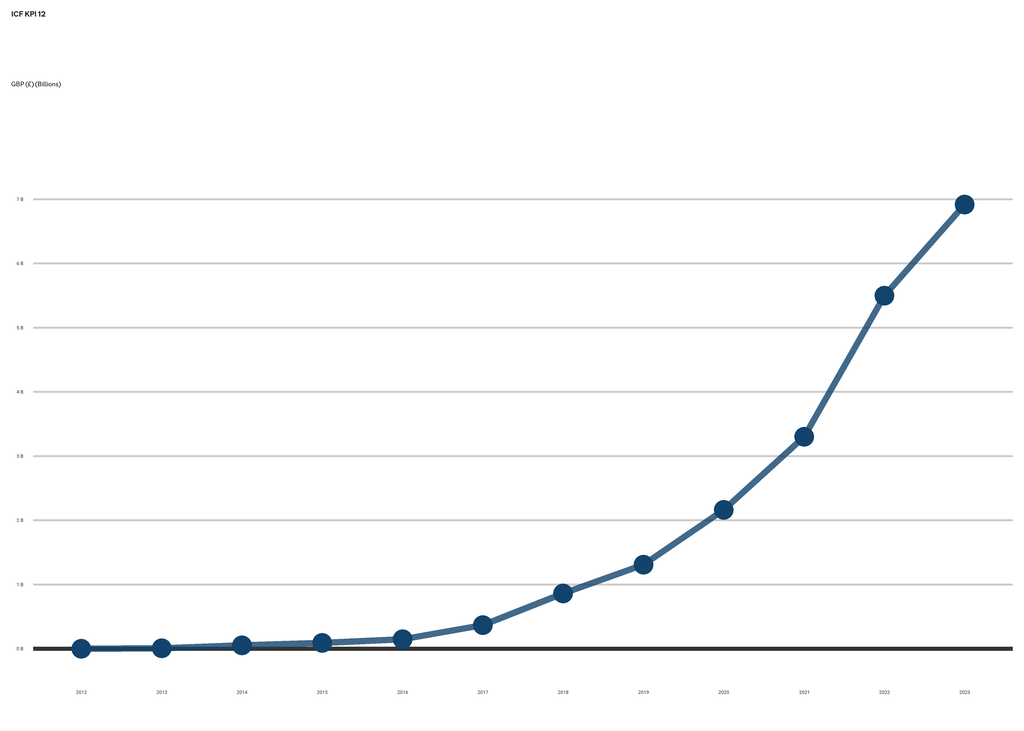

### KPI 15

How many programmes reported: 53

Annual results:

For KPI 15, programmes report the likelihood of transformational change based on available evidence, on a scale from 1 - 5. For this reason, the results cannot be reported cumulatively. Instead we present the distribution of programmes across each score category per year.

In previous years this indicator used a scale from 0 - 4. However, the data model used in our results collation software made it difficult to distinguish between programmes reporting a score of 0 (a true 0) and programmes not reporting in any given year. At the same time, we have improved the definitions of each category, making it easier for reporting teams to score their programmes, while removing ambiguity from data processing steps.

[figure not shown]

### KPI 17

Total achieved from 2011-2023: 2,700,000 Hectares

How many programmes reported: 16

The historical results for this KPI have been revised by: 111,000

The largest increases in results for this KPI in 2022/2023 have come from the following programmes:

| programme_id | programme_title | tot |
| --- | --- | --- |
| BEIS0017 | Forest Carbon Partnership Facility (FCPF -C) - Carbon Fund | 207643 |
| 202817 | Adaptation for Smallholder Agricultural Programme (ASAP) | 191555 |
| BEIS0019 | REDD Early Movers programme (REM) | 106182 |
| 200368 | Support to the multilateral Climate Investment Funds (CIFs) | 53036 |
| BEIS0016 | BioCarbon Fund (BioCF) | 21027 |

Cumulative annual results:

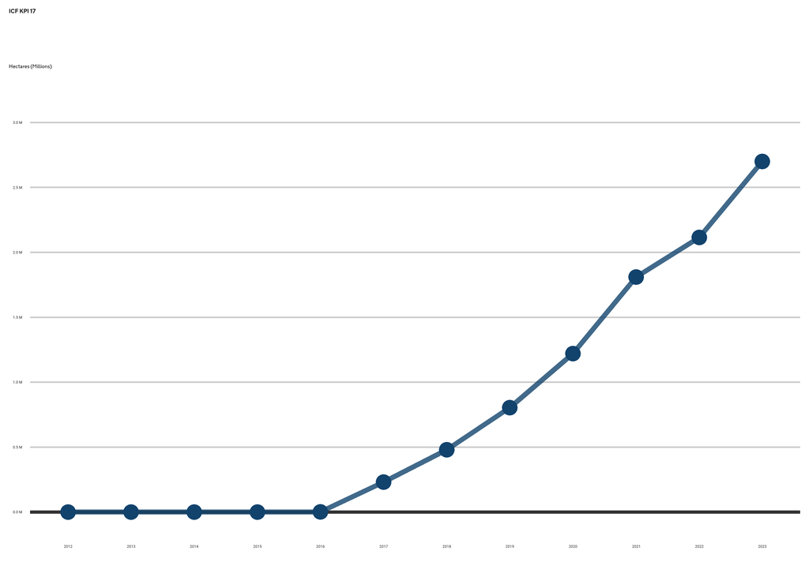

### TA KPI 01

Total achieved from 2011-2023: 124 Countries

How many programmes reported: 37

The largest results for this KPI in 2022/2023 have come from the following programmes:

| programme_id | programme_title | tot |
| --- | --- | --- |
| BEIS0008 | NDC Partnership (NDCP) | 85 |
| 300705 | Delivering ambition of the United Nations Secretary General’s Climate Summit 2019 to build resilience to climate change | 43 |
| DefraPO005 | BIOFIN | 41 |
| BEIS0033 | Energy Sector Management Assistance Programme (ESMAP) | 37 |
| 205142 | The India-UK Global Partnership Programme on Development | 25 |

### TA KPI 02.1

Total achieved from 2011-2023: 174,000 People

How many programmes reported: 25

The largest results for this KPI in 2022/2023 have come from the following programmes:

| programme_id | programme_title | tot |
| --- | --- | --- |
| 202745 | Investments in Forests and Sustainable Land Use | 76537 |
| 301495 | UK Partnering for Accelerating Climate Transitions (UK PACT) | 21517 |
| 301240 | Enabling Development for Girls Education | 3113 |
| BEIS0007 | The Nationally Appropriate Mitigation Actions (NAMA) Facility | 1374 |
| 205118 | Commercial Agriculture for Smallholders and Agribusiness Programme | 1327 |

### TA KPI 02.2

Total achieved from 2011-2023: 1,504 Organisations

How many programmes reported: 28

The largest results for this KPI in 2022/2023 have come from the following programmes:

| programme_id | programme_title | tot |
| --- | --- | --- |
| BEIS0037 | Clean Energy Innovation Facility (CEIF) | 351 |
| BEIS0007 | The Nationally Appropriate Mitigation Actions (NAMA) Facility | 170 |
| BEIS0028 | 2050 Calculator | 167 |
| 205238 | Financial Sector Deepening Africa (FSDA) Platform | 58 |
| 204984 | Climate Smart Development for Nepal | 41 |

### TA KPI 03

Total achieved from 2011-2023: 134 Policies

How many programmes reported: 17

The largest results for this KPI in 2022/2023 have come from the following programmes:

| programme_id | programme_title | tot |
| --- | --- | --- |
| 204984 | Climate Smart Development for Nepal | 38 |
| BEIS0007 | The Nationally Appropriate Mitigation Actions (NAMA) Facility | 15 |
| BEIS0033 | Energy Sector Management Assistance Programme (ESMAP) | 13 |
| PRP IND 001007 | ASPIRE ( Accelerating Smart Power and Renewable Energy in India) | 5 |
| 205238 | Financial Sector Deepening Africa (FSDA) Platform | 4 |

### TA KPI 05

Total achieved from 2011-2023: 35,001,000 Tonnes of CO2 (tCO2e)

How many programmes reported: 6

The largest results for this KPI in 2022/2023 have come from the following programmes:

| programme_id | programme_title | tot |
| --- | --- | --- |
| 202745 | Investments in Forests and Sustainable Land Use | 12724548 |
| BEIS0007 | The Nationally Appropriate Mitigation Actions (NAMA) Facility | 2546431 |
| 203427 | Accelerating Investment and Infrastructure in Nepal | 97050 |
| 300702 | Accelerating Ethiopia’s Economic Transformation | 1 |
| 202214 | Malawi Health Sector Support Programme | 0 |

# Appendix

### Data disaggregation

Note: some programmes were only able to provide disaggregated data at the cumulative level (no annual breakdown); these have not currently been included in this summary but we hope to update this in the near future.

(Direct beneficiaries only)

KPI 2.2, KPI 8, KPI 15 and KPI 17 do not include results disaggregations.

### ICF Expected total programme benefits

Expected total programme benefits include all past and future benefits from current or previous ICF programmes. Benefits include those expected to be delivered after a programme has closed.

| kpi_id | tpb |
| --- | --- |
| ICF KPI 01 | 924,900,000 People |
| ICF KPI 02.1 | 97,500,000 People |
| ICF KPI 02.2 | 457 Institutions |
| ICF KPI 04 | 50,600,000 People |
| ICF KPI 06 | 930,900,000 Tonnes of CO2 (tCO2e) |
| ICF KPI 07 | 6,951 Megawatts (MW) |
| ICF KPI 08 | 42,000,000 Hectares |
| ICF KPI 10 | 636,600,000 GBP (£) |
| ICF KPI 11 | 12,297,600,000 GBP (£) |
| ICF KPI 12 | 8,609,600,000 GBP (£) |
| ICF KPI 15 | Not Applicable |
| ICF KPI 17 | 20,600,000 Hectares |
| ICF TA KPI 01 | Not Applicable |
| ICF TA KPI 02.1 | 100,000 People |
| ICF TA KPI 02.2 | 1,014 Organisations |
| ICF TA KPI 03 | 64 Policies |
| ICF TA KPI 05 | 176,900,000 Tonnes of CO2 (tCO2e) |

### List of programmes that have contributed to the ICF results (2011/2012 - 2022/2023)

This includes all programmes that have reported ICF results. These programmes range from fully ICF funded to only included a small ICF component. Further details of programmes can be found on [DevTracker](https://devtracker.fcdo.gov.uk/)

| programme_id | programme_title |
| --- | --- |
| PRP IND 001007 | ASPIRE ( Accelerating Smart Power and Renewable Energy in India) |
| PRP IND 001005 | UK - Niti Aayog Electric Mobility Accelerator Programme |
| PRP IND 001002 | Exploring Policy and Institutional arrangements for advancing City - Decarbonisation |
| PRP IND 001004 | Voluntary Contribution to support IEA activities in India within Clean Energy Transitions Programme |
| GB-GOV-52-CSSF-06-000023 | Conflict, Stability and Security Fund (CSSF) Middle East Peace Process |
| GB-GOV-50-PF-13B-INJRE | Indonesia Renewable Energy Programme (MENTARI) |
| DefraPO023 | Global Fund for Coral Reefs (GFCR) |
| DefraPO022 | Ocean Risk and Resilience Action Alliance (ORRAA) |
| DefraPO021 | Ocean Country Partnership Programme (OCPP) |
| DefraPO020 | Global Plastic Action Partnerships (GPAP) |
| DefraPO018 | Cities4Forests |
| DefraPO013 | Low Carbon Agriculture and Avoided Deforestation in Brazil - Phase 2 (Rural Sustentavel Phase 2) |
| DefraPO012 | Low Carbon Agriculture and Avoided Deforestation in Brazil - Phase 1 (Rural Sustentavel Phase 1) |
| DefraPO009 | Land Degradation Neutrality Fund |
| DefraPO005 | BIOFIN |
| DefraPO004 | Sustainable cold chain solutions (F-gases) |
| DefraPO003 | The eco.business Fund |
| DefraPO002 | Reducing Deforestation and Forest Fires in the Brazilian Cerrado |
| DefraPO001 | Blue Forests Initiative |
| BEIS025 | Carbon Initiative for Development (Ci-Dev) |
| BEIS009 | Global Energy Transfer Feed-in Tariff (GETFiT) |
| BEIS0040 | Mobilising Finance for Forests (MFF) |
| BEIS0038 | Partnerships for Market Implementation (PMI) |
| BEIS0037 | Clean Energy Innovation Facility (CEIF) |
| BEIS0036 | Climate Finance Accelerator (CFA) |
| BEIS0034 | Capacity Building for International Negotiations (CASA) |
| BEIS0033 | Energy Sector Management Assistance Programme (ESMAP) |
| BEIS0032 | Market Accelerator for Green Construction (MAGC) |
| BEIS0029 | Knowledge, Evidence and Engagement Portfolio (KEEP) |
| BEIS0028 | 2050 Calculator |

[output cut: 267 more lines]

[^1]: [UN SDG Report](https://unstats.un.org/sdgs/report/2022/The-Sustainable-Development-Goals-Report-2022.pdf)
[^2]: [UN SDG Report](https://unstats.un.org/sdgs/report/2022/The-Sustainable-Development-Goals-Report-2022.pdf)
[^3]: [IPCC 6th Assessment Report WGII](https://www.ipcc.ch/report/ar6/wg2/downloads/report/IPCC_AR6_WGII_SummaryForPolicymakers.pdf)
[^4]: [UN SDG Report](https://unstats.un.org/sdgs/report/2022/The-Sustainable-Development-Goals-Report-2022.pdf)
[^5]: [IPCC 6th Assessment Report WGIII](https://www.ipcc.ch/report/ar6/wg3/downloads/report/IPCC_AR6_WGIII_SPM.pdf)
[^6]: [COP26 Glasgow Climate Pact](https://ukcop26.org/wp-content/uploads/2021/11/COP26-Presidency-Outcomes-The-Climate-Pact.pdf)
[^7]: [UNFCCC Paris Agreement](https://unfccc.int/process-and-meetings/the-paris-agreement/the-paris-agreement)